# Лабораторная работа № 6

Основы интерфейса взаимодействия пользователя с системой Unix на уровне командной строки

Прозорова Е. Е.

Российский университет дружбы народов, Москва, Россия

20 марта 2025

# Информация

## Докладчик

- Прозорова Елизавета Евгеньевна
- студент факультета ФМиЕН
- группа НММбд-03-24
- Российский университет дружбы народов
- 1132246767@pfur.ru

# Вводная часть

## Цели и задачи

- Приобретение практических навыков взаимодействия пользователя с системой посредством командной строки.

# Выполнение лабораторной работы

## Домашний каталог

Я определила имя домашнего каталога через Thunar.

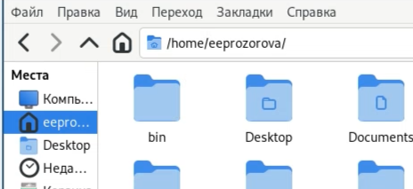

Домашний каталог

## Содержимое каталога tmp

Я перешла в каталог /tmp/ и вывела его содержимое с помощью ls. с различными опциями.

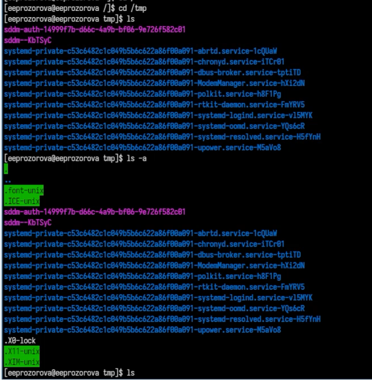

Содержимое каталога tmp

Затем я перешла в каталог /var/spool чтобы посмотреть есть ли там подкаталог с именем cron. Он есть.

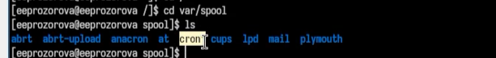

Каталог var/spool с подкаталогом cron

## Каталог newdir и morefun

В домашнем каталоге создала новый каталог с именем newdir, в котором создала новый каталог с именем morefun.

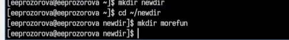

Каталог newdir и morefun

## Каталоги с именами letters, memos, misk

В домашнем каталоге создала одной командой три новых каталога с именами letters, memos, misk. Затем удалила эти каталоги одной командой.

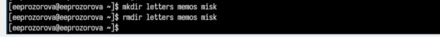

Каталоги с именами letters, memos, misk

## Удаление newdir

Затем я попробовала удалить newdir командой rm, у меня не получилось. Тогда я попробовала rmdir, тоже не получилось. После этого я использовала команду rm -r, она сработала.

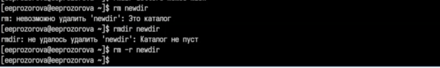

Удаление newdir

## Команда man

Теперь я ввела команду man.

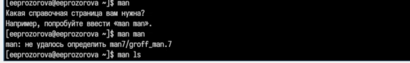

Команда man

Команда man на ls.

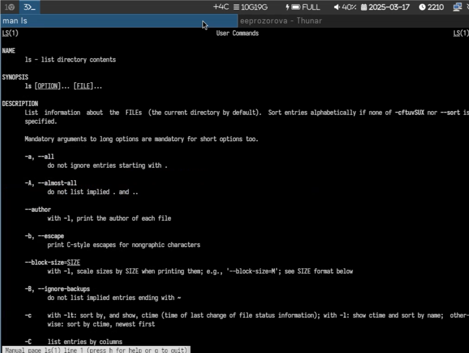

Внутренности ls

Я определила опцию команды ls, которую нужно использовать для просмотра содержимое не только указанного каталога, но и подкаталогов, входящих в него.

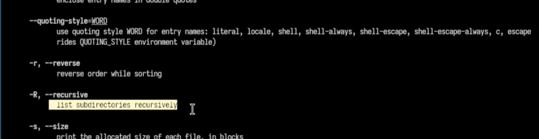

Опция ls

## Опции команды ls

Затем я определила набор опций команды ls, позволяющий отсортировать по времени последнего изменения выводимый список содержимого каталога с развёрнутым описанием файлов.

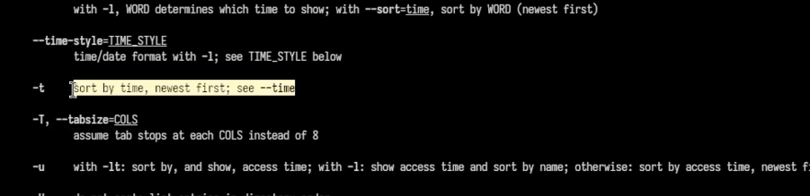

Опция команды ls для сортировки содержимого каталога по времени

## cd

Я использовала команду man для просмотра описания команды cd.

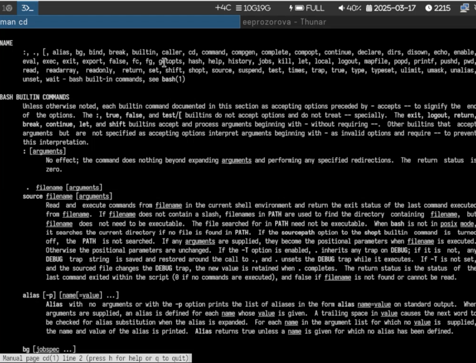

## pwd

Просмотр описания команды pwd.

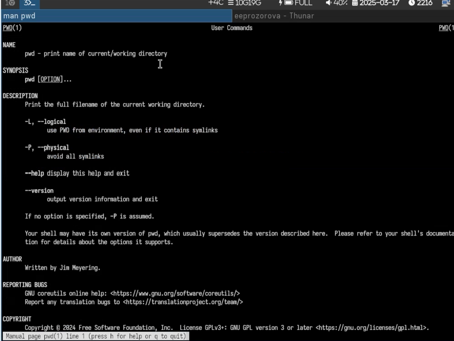

Описание pwd

## mkdir

Просмотр описания команды mkdir.

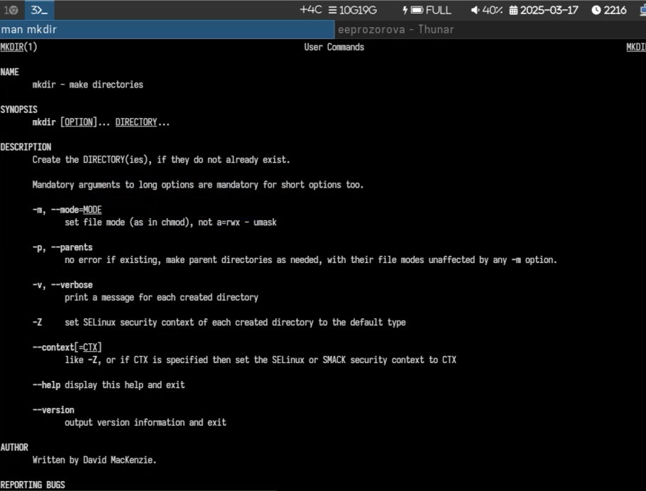

Описание mkdir

## rm

Просмотр описания команды rm.

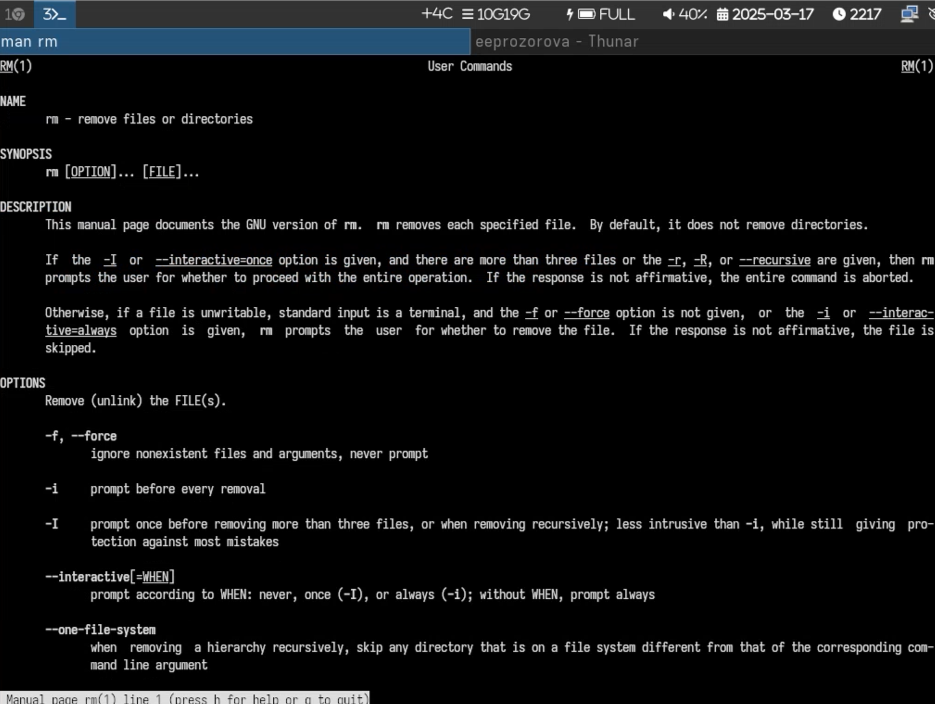

Описание rm

## History

Затем я посмотрела что делает команда history.

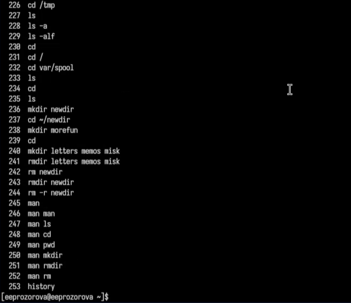

History

# Выводы

В ходе работы я приобрела навыки работы с системой посредством командной строки.